# SBWD 16S processing

Emily Smenderovac, edited by Maddie McCaig

2023-11-24

## ## Sequencing/Bioinformatics Outline

- Leaf samples broken down, homogenized, and frozen at GLFC
- DNA extracted using the Qiagen PowerSoil Kit
- DNA sequenced via metabarcoding via the GRDI ecobiomics project (16S, ITS)
- Sequence data processed using the MetaWorks pipeline version 1.10.0 (Porter, T.M., Hajibabaei, M. 2020. METAWORKS: A flexible, scalable bioinformatic pipeline for multi-marker biodiversity assessments. BioRxiv, doi: https://doi.org/10.1101/2020.07.14.202960)
- Processed sequence data with samples containing <1000 seq removed
- Sequence data was not rarefied as read counts reached a plateau
- Raw data (after bioinformatic processing no rarefaction) can be found in file ending with results.csv.

Bioinformatics run steps: 1- transfer raw seq files to data file 2- cp pipeline files to live.run 3- cd to live.run folder 4- create/activate conda environment 5- rename raw seq files as need to match config_ESV file 6- edit config_ESV file 7- run using snakemake 8- move results files to archive 9- run CM.processing.R code to generate run stats and rarefied community matrix 10- rm raw seq data

*See https://github.com/terrimporter/MetaWorks for specific details on MetaWorksv1.10.0 pipeline

Version notes: Conda v4.9.1 RDP 2.13 Bacteria_RDP-built-in

Primer information:

1.16Sv4v5 * Forward “515F” (): sequence = GTGCCAGCMGCCGCGGTAA * Reverse “926R” (): sequence = AAACTYAAAKRAATTGRCGG

## Copied fastq’s to Linux directory and renamed

```bash
##Prepare files for run - notes move or link all files to "live.run" folder
#create the bioinformatics folder that this is being saved in
mkdir Bioinformatics
cd Bioinformatics
mkdir current.pipelines
mkdir live.run
mk.dir current.reference.sets

#Latest MetaWorks pipeline
wget https://github.com/terrimporter/MetaWorks/releases/download/v1.10.0/MetaWorksv1.10.0.zip -p ~/Bioinformatics/current.pipelines/
unzip ~/Bioinformatics/current.pipelines/MetaWorksv1.10.0.zip
#Download RDP classifier if haven't already
wget https://phoenixnap.dl.sourceforge.net/project/rdp-classifier/rdp-classifier/rdp_classifier_2.13.zip -p ~/Bioinformatics/live.run/
#ORFfinder
#this is for psuedogene filtering, shouldn't need it for this project
#wget ftp://ftp.ncbi.nlm.nih.gov/genomes/TOOLS/ORFfinder/linux-i64/ORFfinder.gz
#gunzip ORFfinder.gz
#not sure what chmod 755 does?? something about user permissions
#chmod 755 ORFfinder
#mv ORFfinder ~/miniconda3/envs/MetaWorks_v1.10.0/bin/.
```

```bash
## Set up directories for processing
cd Bioinformatics
cd current.pipelines
cp -r  MetaWorksv1.10.0 live.run

cd live.run

mkdir 16S_fastq
## copy over files
cp ../../../EnvChem/project_data_Emilson/SBWD/leafpack_microbes/*16S_fastq_files/* 16S_fastq

## fix file names for parsing

cd 16S_fastq

rename  \.fq \.fastq  *

for f in *; do mv "$f" "${f//_16S_*_R/_R}"; done
for f in *; do mv "$f" "${f//GRDI-ECO_*_AM-EE-/}"; done


cd ..

conda activate MetaWorks_v1.10.0

## config file was edited at this point - if necessary ### standard 16S config file is MetaWorks1.8.1 folder, also added 16S_adapters.fasta with appropriate sequences

#Run script after editing config.yaml file
snakemake --jobs 36 --snakefile snakefile_ESV --configfile config_ESV_16S.yaml

cp config_ESV_16S.yaml 16S
cp 16S_adapters.fasta 16S

rm -r 16S_fastq
mv 16S ../../SBWD/16S
```

```bash
## get files over to appropriate folder
#Maddie might not have admin privelages to do this, if not talk to Emily and she can help
mkdir EnvChem/wet_analyses_bioinformatics_archive/SBWD

scp -r esmender@132.156.202.255:Bioinformatics/SBWD/16S/* E:/wet_analyses_bioinformatics_archive/SBWD/SBWD_16S_20220601
```

## QAQC of Metabarcoding Data

```r
library(dplyr)
library(vegan)
library(readr)
library(tidyverse)
PROJ.ID <- "SBWD"
amplicon <- "16S"

drive <- "//NRONP6AwvFSP001/EnvChem"

## pull the processing that has been done most recently
archives <- list.dirs(paste(drive, "wet_analyses_bioinformatics_archive", PROJ.ID, sep="/"), recursive = FALSE)

archives <- grep(paste(amplicon, "[[:digit:]]+$", sep="_"), archives, value = TRUE)
archives_date <- as.POSIXct(str_extract(archives, "[[:digit:]]+$"), format = "%Y%m%d")
archive <- archives[archives_date == max(archives_date)]

rm(archives, archives_date)
```

## Summary of Sequence counts before and after primer trimming

```r
## Import data
summary.table.1 <- data.frame()
for(stat in c("R1", "R2", "paired", "trimmed")){
  temp <-  as.data.frame(read.delim(paste(archive, "stats", paste0(stat, ".stats"), sep = "/"), header = TRUE))
  temp.sum <- as.data.frame(as.list(c(sum(temp$TotSeqs),mean(temp$TotSeqs), mean(temp$MinLength), mean(temp$MaxLength), mean(temp$MeanLength))),col.names=c("Total seq number (across samples)","Mean seq number (per sample)", "min seq length","max seq length","mean seq length"), check.names = FALSE)
  summary.table.1 <- rbind(summary.table.1, temp.sum)
  assign(stat, temp)
  rm(temp, temp.sum)
}
rownames(summary.table.1) <- c("R1", "R2", "paired", "trimmed")

## export summary table
write.csv(summary.table.1,file=paste0(archive,"/SummaryStats_",PROJ.ID,"_",Sys.Date(),"_",amplicon,".csv"))

knitr::kable(summary.table.1)
```

|  | Total seq number (across samples) | Mean seq number (per sample) | min seq length | max seq length | mean seq length |
| --- | --- | --- | --- | --- | --- |
| R1 | 18737279 | 63732.24 | 106.5306 | 264.1667 | 262.8344 |
| R2 | 18737279 | 63732.24 | 106.4660 | 264.1667 | 262.9219 |
| paired | 14277468 | 48562.82 | 100.7075 | 474.1735 | 408.1641 |
| trimmed | 13992603 | 47593.89 | NA | NA | NA |

## Summary of dereplication and chimera removal

```r
dereplication <- read.csv(paste(archive,  "dereplication.log", sep = "/"), header = FALSE)
dereplication<-as.list(c(as.character(dereplication$V1[5]),as.character(dereplication$V2[4]), as.character(dereplication$V3[4]), as.character(dereplication$V4[4])))
dereplication[1]<-gsub(" unique sequences", "", dereplication[1])
dereplication[2]<-gsub(" min ", "", dereplication[2])
dereplication[3]<-gsub(" max ", "", dereplication[3])
dereplication[4]<-gsub(" avg ", "", dereplication[4])

chimeraRemoval <- read.csv(paste(archive, "chimeraRemoval.log", sep = "/"), header=FALSE)
chimeraRemoval<-as.list(c(as.character(chimeraRemoval$V1[12]),as.character(chimeraRemoval$V2[4]), as.character(chimeraRemoval$V3[4]), as.character(chimeraRemoval$V4[4])))
chimeraRemoval[1]<-gsub("F230/cat.denoised: 66/9694 chimeras ", "", chimeraRemoval[1])
chimeraRemoval[2]<-gsub(" min ", "", chimeraRemoval[2])
chimeraRemoval[3]<-gsub(" max ", "", chimeraRemoval[3])
chimeraRemoval[4]<-gsub(" avg ", "", chimeraRemoval[4])

dereplication <- as.data.frame(dereplication, col.names=c("number","min", "max", "mean"))
chimeraRemoval <- as.data.frame(chimeraRemoval, col.names=c("number","min", "max", "mean"))
summary_table2 <- rbind(dereplication, chimeraRemoval)
row.names(summary_table2) <- c("dereplication", "chimera removal")
knitr::kable(summary_table2)
```

|  | number | min | max | mean |
| --- | --- | --- | --- | --- |
| dereplication | 3103157 | 150 | 458 | 372 |
| chimera removal | 16S/cat.denoised: 6854/32145 chimeras (21.3%) | 150 | 449 | 372 |

## Community Matrix and Rarefaction Curves

```r
tax <- read.csv(paste(archive, "results.csv", sep="/"))
nrow.orig <- nrow(tax)

##tax.check <- tax[!complete.cases(tax), ]

## remove rows that aren't Fungi
tax <- tax[grep("Bacteria|Archaea", tax$Domain), ]

print(paste0("Number of ASVs removed based on ID as not Bacteria or Archaea: ", nrow.orig-nrow(tax)))
```

```
## [1] "Number of ASVs removed based on ID as not Bacteria or Archaea: 1814"
```

```r
## Remove amplicon from ESV names and rename as GlobalESV

tax[,1] <- sub(paste0(amplicon, "\\_"), "", tax[,1])
colnames(tax)[1] <- "GlobalESV"
```

## ESV table creation

```r
ESV <- tax %>%
  group_by(SampleName) %>%
  # filter out any samples less than 1000 reads ## also removes any taxa that would now be = 0
  filter(sum(ESVsize) > 1000) %>%
  pivot_wider(names_from = SampleName, values_from = ESVsize, values_fn = sum, values_fill = 0) %>%
  column_to_rownames("GlobalESV")

print(paste0(str_c(unique(tax$SampleName)[!unique(tax$SampleName) %in% colnames(ESV)], collapse = ", "), " removed due to low read count (<1000)."))
```

```
## [1] "UQAM_U02_1_20220901_16S_16SM03992, UQAM_L12_5_20220901_16S_16SM03992 removed due to low read count (<1000)."
```

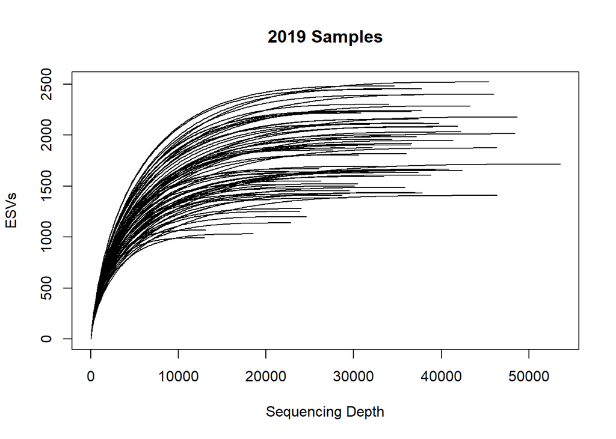

```r
rarecurve(t(ESV[,colnames(ESV) %in% grep("2019", tax$SampleName, value = T)]), step = 171, ylab="ESVs", xlab="Sequencing Depth", main = "2019 Samples", label = FALSE)
```

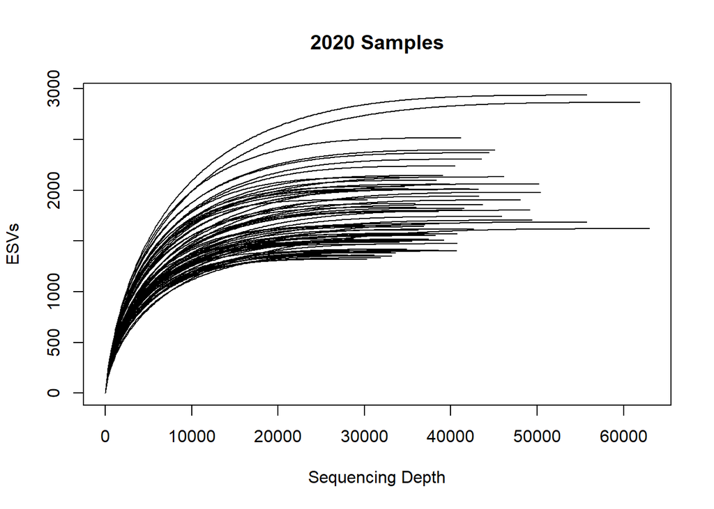

```r
rarecurve(t(ESV[,colnames(ESV) %in% grep("2020", tax$SampleName, value = T)]), step = 171, ylab="ESVs", xlab="Sequencing Depth", main = "2020 Samples", label = FALSE)
```

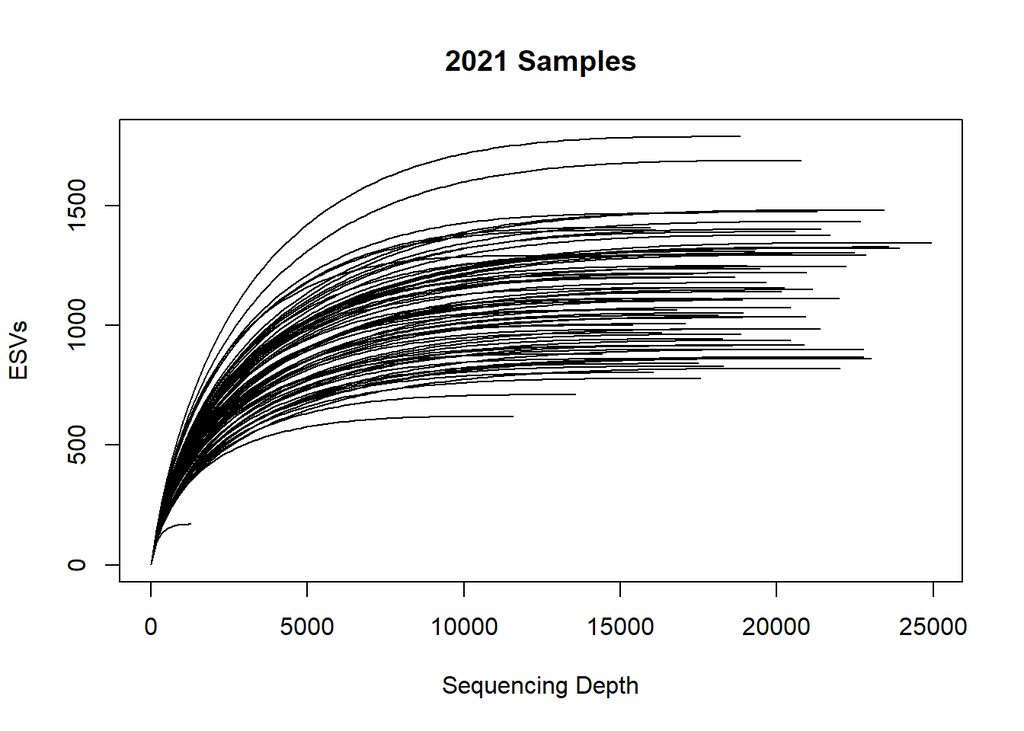

```r
rarecurve(t(ESV[,colnames(ESV) %in% grep("2021", tax$SampleName, value = T)]), step = 171, ylab="ESVs", xlab="Sequencing Depth", main = "2021 Samples", label = FALSE)
```

Data look to be reaching plateau for most samples, so data were not rarefied for subsequent analyses.

```r
#clean up dataset and export
#fix column names (want only C04_4_2019)
#for columns 26 to 239
names(ESV)[20:234] <- substr(names(ESV)[20:234],1,10)

datayears <- as.numeric(unique(str_sub(str_extract(tax$SampleName, "_[[:digit:]]{2,}_.+$"),2,5)))

## Write the cleaned ESV data to the appropriate project data folder
write.csv(ESV, paste(drive, "project_data_Emilson", PROJ.ID, "leafpack_microbes", paste0(PROJ.ID, "_",  min(datayears), "-", max(datayears), "_lp_", tolower(amplicon), ".csv"), sep="/"))
```